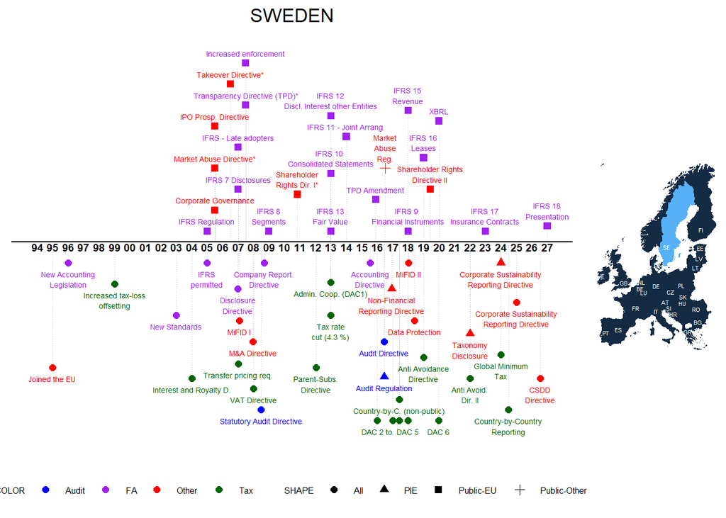

Notes: The graph depicts major regulatory changes that we identified via an extensive literature search, an online survey of mentioned authors, and other sources. Please note that the graph does not include all possible regulatory changes, e.g. minor revisions to local GAAP or tax rate changes below 3% are not included. The dates of EU Directives are based on the official transposition deadlines unless denoted with a *, in which case we included the entry-to-force date as identified in the literature. For more information, please go to [Labro and Pierk (2023)](http://www.eu-regulations.com/Labro_Pierk_2023.pdf). We kindly ask that you cite the paper if you use the information on this website in your research project. Do you have comments or see anything missing? Please email us!

## Regulations, Publications, Further Graphs

The tab ‘Regulations’ includes links to the regulations, gives short descriptions, and provides selective papers for further reading. If the regulation is a national transposition of an EU Directive, the link to the Directive is given. The tab ‘Number of Regulations’ shows graphically the number of regulations 8 years around the respective year (-4,-3,-2,-1,0,+1,+2,+3). The tab ‘Number of Categories” shows graphically the number of different categories 8 years around the respective year (-4,-3,-2,-1,0,+1,+2,+3). The tab ’Publications’ shows all publications that include the countries’ names and variations thereof in the title, abstract, or keywords. Similarly, the tab ‘SSRN’ shows papers of the SSRN Accouning Research Network that include the countries’ names and variations.

### Regulations

[output not shown]

[output cut: 48 more lines]

### Number of Regulations

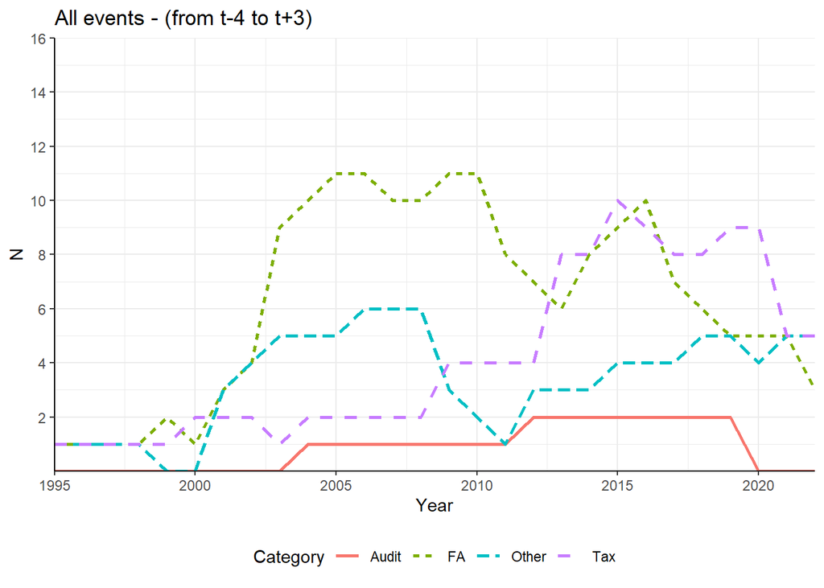

### Number of Categories

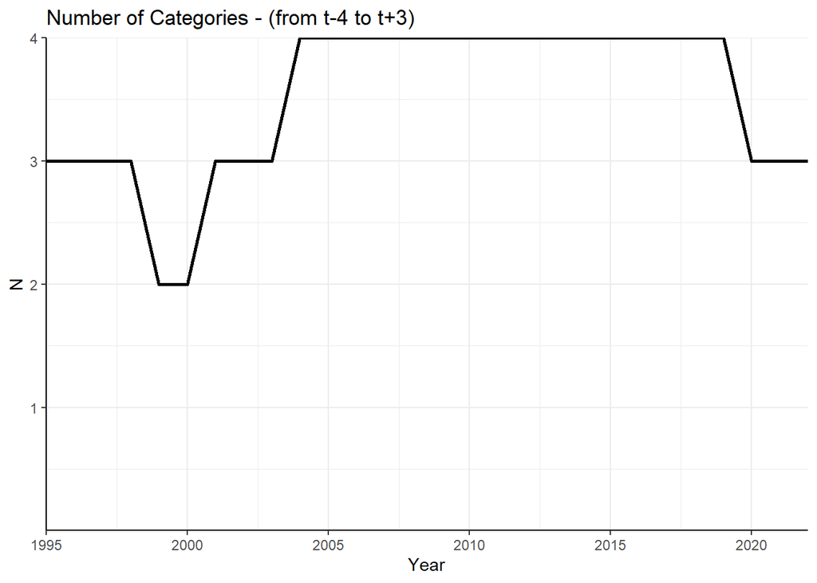

### Publications

|  | authors | title | year | journal |
| --- | --- | --- | --- | --- |
| 1 | Ax C., Ax E. | when the supply side of a management accounting innovation fails–the case of beyond budgeting in sweden | 2021 | Accounting and Business Research |
| 2 | Bonsón E., Lavorato D., Lamboglia R., Mancini D. | artificial intelligence activities and ethical approaches in leading listed companies in the european union | 2021 | International Journal of Accounting Information Systems |
| 3 | Frii P., Hamberg M. | what motives shape the initial accounting for goodwill under ifrs 3 in a setting dominated by controlling owners? | 2021 | Accounting in Europe |
| 4 | Gerdin J., Englund H. | vertical, horizontal, and self control in academia: survey evidence on their diverging effects on perceived researcher autonomy and identity | 2021 | British Accounting Review |
| 5 | Höglund L., Mårtensson M., Thomson K. | strategic management, management control practices and public value creation: the strategic triangle in the swedish public sector | 2021 | Accounting, Auditing and Accountability Journal |
| 6 | Maine J., Florin Samuelsson E., Uman T. | ambidextrous sustainability, organisational structure and performance in hybrid organisations | 2021 | Accounting, Auditing and Accountability Journal |
| 7 | Saastamoinen J., Savolainen H. | does a leopard change its spots? auditors and lawyers as valuation experts for minority shareholders in the judicial appraisal of private firms | 2021 | Journal of Business Finance and Accounting |
| 8 | Englund H., Gerdin J. | contesting conformity: how and why academics may oppose the conforming influences of intra-organizational performance evaluations | 2020 | Accounting, Auditing and Accountability Journal |
| 9 | Hartmann B., Marton J., Andersson Sols J. | ifrs in national regulatory space: insights from sweden | 2020 | Accounting in Europe |
| 10 | Wällstedt N. | sources of dissension: the making and breaking of the individual in swedish aged care | 2020 | Accounting, Organizations and Society |

[output cut: 68 more lines]

### SSRN

|  | authors | title | Posted | Revised |
| --- | --- | --- | --- | --- |
| 1 | Qazi Awais Amin | firms cash management, adjustment cost and its impact on firms’ speed of adjustment: a cross country analysis | 2021-11-18 |  |
| 2 | Conny Overland, Svetlana Sabelfeld and Niuosha Samani | employee representatives, employee related disclosures, and the implementation of the non-financial reporting directive | 2021-09-04 |  |
| 3 | Axel Hilling, Frederik Lundtofte, Niklas Sandell, Amanda Sonnerfeldt and Anders Vilhelmsson | tax avoidance and state ownership – the case of sweden | 2021-08-31 |  |
| 4 | Mahmoud Hosseinniakani, Conny Overland and Niuosha Samani | management’s and auditors’ disclosures of significant accounting estimates and the role of audit committees | 2021-08-13 |  |
| 5 | Ting Dong | gender salary gap in the auditing profession: trend and explanations | 2021-07-08 | 2022-01-21 |
| 6 | Christian Ax and Elin Ax | when the supply side of a management accounting innovation fails – the case of beyond budgeting in sweden | 2021-05-26 | 2021-06-29 |
| 7 | Dan Johansson, Mikael Stenkula and Gunnar Du Rietz | capital income taxation of swedish households, 1862–2010 | 2021-04-20 |  |
| 8 | Erik Johannesson | former insiders' trading | 2021-04-16 |  |
| 9 | Sven Siverbo | the impact of management controls on public managers’ well-being | 2021-04-03 |  |
| 10 | Ting Dong, Juha-Pekka Kallunki, Henrik Nilsson and Ann Vanstraelen | the labor market return to auditors’ leadership ability | 2021-04-01 | 2021-12-08 |

[output cut: 6 more lines]